## Introduction

This markdown file records me practicing using the **chAMP** package.  
There are 8 samples being analyzed, which are cfDNA from 4 healthy volunteers and 4 lung cancer patients. The sentrix_ID is 205379740133, and all samples are included in it.

#### Loading and filtering data

```r
library(ChAMP)
```

```r
myLoad <- champ.load(directory = "C:/InfiniumMeth/testsample/205379740133", arraytype = "EPIC")
```

```
##        Failed CpG Fraction.
## HV_C_1         0.0025822307
## HV_C_2         0.0017322656
## HV_C_3         0.0019355181
## HV_C_4         0.0013280703
## LC_C_1         0.0007876034
## LC_C_2         0.0013038186
## LC_C_3         0.0060894912
## LC_C_4         0.0465852425
```

Notice that the last sample, LC_C_4, has a rather high proportion of failed probes, which might affect the downstream analysis.  
According to the `champ.filter()` criteria, there are some probes being filtered out:  
1. A detection p-value above 0.01: **42312** probes  
2. A beadcount <3 in at least 5% of samples: **9046** probes  
3. non-CpG probes: **2406** probes  
4. Probes with SNPs using general EPIC SNP list according to Zhou’s Nucleic Acids Research Paper 2016: **93441** probes  
5. Probes that align to multiple locations that identified in Nordlund et al: **11** probes  
6. Probes located on X,Y chromosome: **15885** probes

There are a total of **702817** probes remained after filtering.

#### Quality control and Normalization

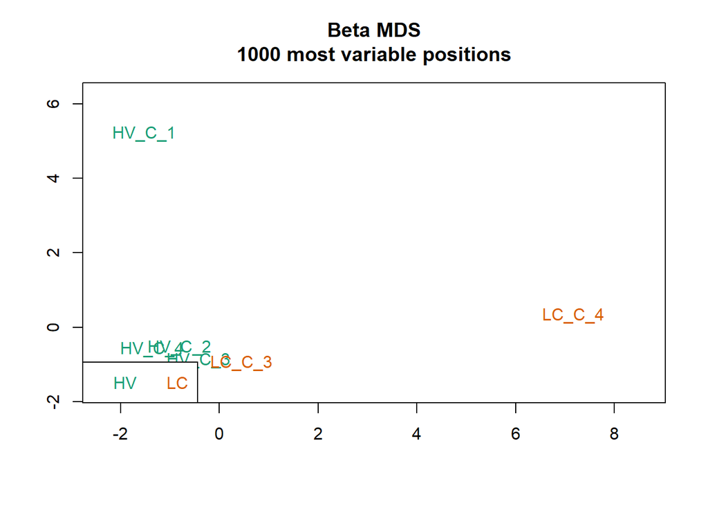

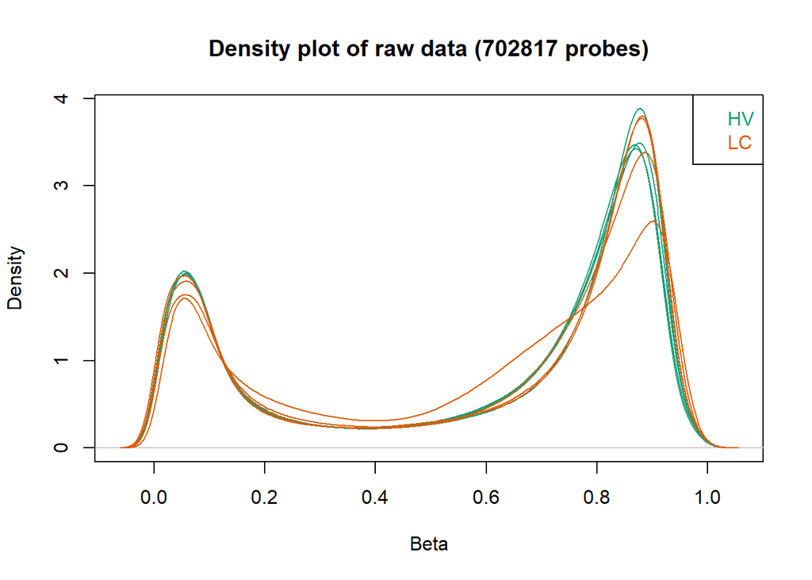

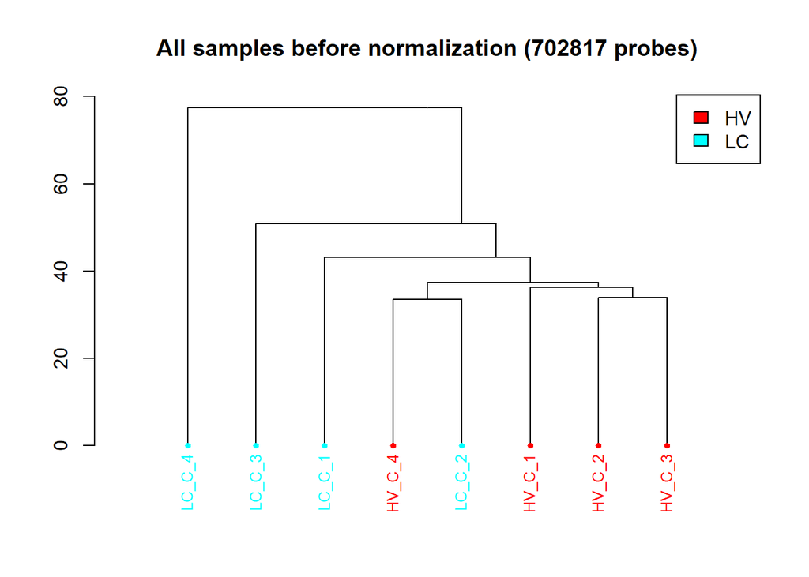

```r
champ.QC(PDFplot = FALSE)
```

The beta value distribution of LC_C_4 in the density plot, which is quite different from the others, may be caused by the high proportional of failed probes.

```r
myNorm <- champ.norm(arraytype = "EPIC", cores = 5)
```

The default method of normalization is [BMIQ](https://pubmed.ncbi.nlm.nih.gov/23175756/).

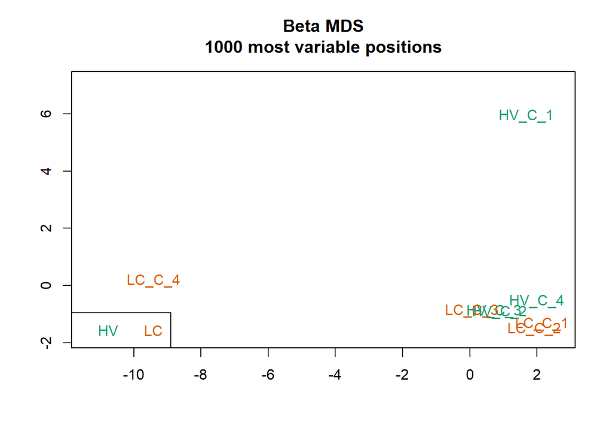

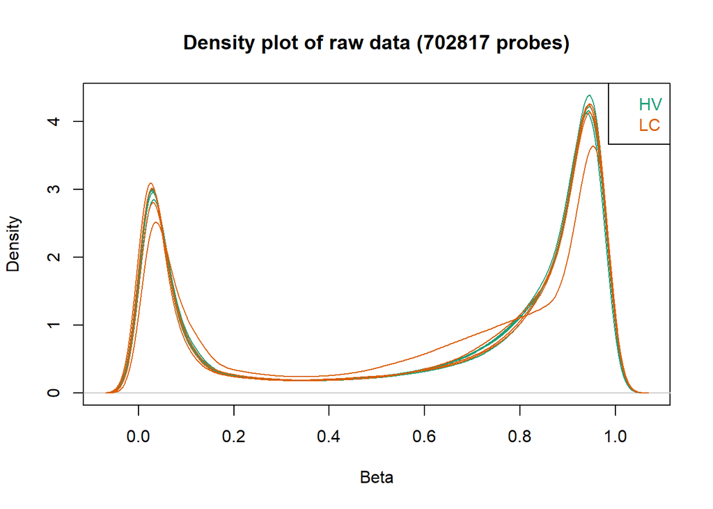

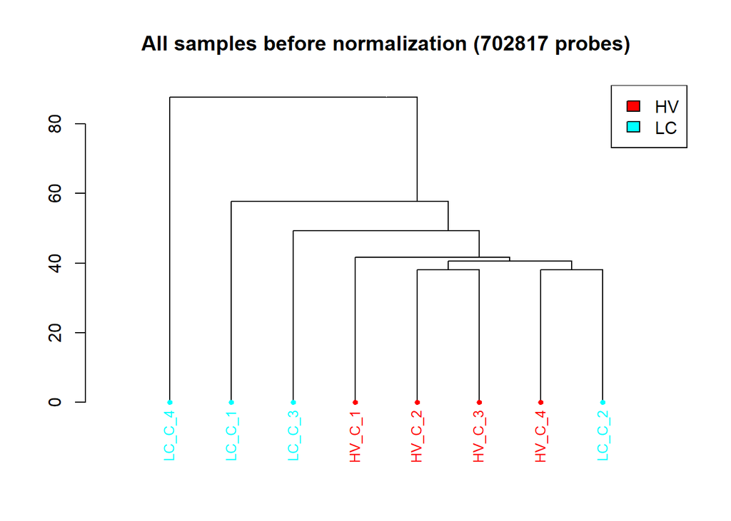

```r
champ.QC(beta = myNorm, PDFplot = FALSE)
```

#### Singular value decomposition and batch effect correction

To see if the variation of the data comes from any technical sources besides the biological factors of our interest, a SVD test is performed.

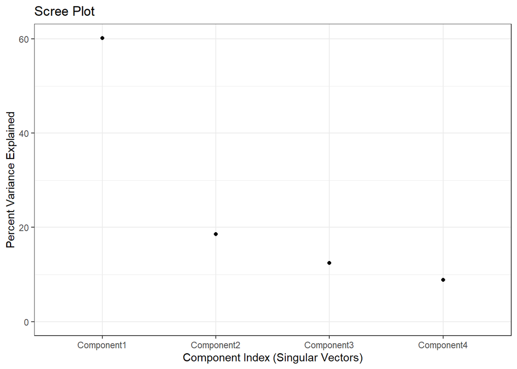

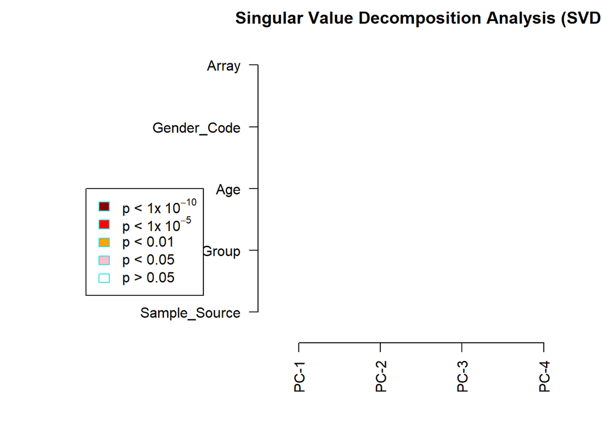

```
##      Sample_Source Sample_Group       Age Gender_Code     Array
## [1,]     0.4288799   0.56370286 0.3286227   0.2482131 0.4288799
## [2,]     0.4288799   0.24821308 0.3286227   0.2482131 0.4288799
## [3,]     0.4288799   0.08326452 0.3286227   1.0000000 0.4288799
## [4,]     0.4288799   0.24821308 0.3957757   0.5637029 0.4288799
```

```r
myNorm <- as.data.frame(myNorm)
champ.SVD(PDFplot = FALSE)
```

It shows that after deconvolution, the first 2 components captured about 80% of variance. In concordance with the SVD analysis plot, implying that there is a minor need to deal with batch effects. It is reasonable since eight samples are all on the same slide.

#### Identification of defferential methylation probes

```r
champ.DMP(arraytype = "EPIC")
```

```
##       Contrasts
## Levels pLC-pHV
##    pHV      -1
##    pLC       1
```

```
## Error in champ.DMP(arraytype = "EPIC"): ChAMP.DMP Have not detected even one significant CpGs. You may try other threshold.
```

It turns out that there are no significant CpGs detected.  
To see if the result is caused by the inclusion of the sample with poor quality (i.e. LC_C_4), LC_C_4 is excluded from the data and the analysis is re-performed.